# 1. Statistical relative protein quantification: SRM, DDA and DIA experiments

`MSstats` is an open-source R-based package for statistical relative quantification of peptides and proteins in mass spectrometry-based proteomic experiments. This document describes `MSstats`, the most recent version of the package, and its use through the command line.

## Applicability

`MSstats` version 3.0 and above is applicable to multiple types of sample preparation, including label-free workflows, workflows that use stable isotope labeled reference proteins and peptides, and workflows that use fractionation. It is applicable to targeted Selected Reaction Monitoring (SRM), Data-Dependent Acquisition (DDA or shotgun), and Data-Independent Acquisition (DIA or SWATH-MS). It is applicable to experiments that make arbitrary complex comparisons of experimental conditions or times.

`MSstats` is currently not applicable to experiments that compare multiple metabolically labeled endogenous samples within a same run. It is not applicable to experiments with iTRAQ labeling. These experiments will be supported in the future.

## Statistical functionalities

`MSstats` version 3.0 and above performs three analysis steps. The first step, *data processing and visualization*, transforms and normalizes the intensities of the peaks, and generates workflow-specific and customizable numeric summaries for data visualization and quality control.

The second step, *statistical modeling and inference*, automatically detects the experimental design (e.g. group comparison, paired design or time course, presence of labeled reference peptides or proteins) from the data. It then reflects the experimental design, the type of spectral acquisition strategy, and the scope of conclusions (e.g. restricted to the subjects, or expanded to the underlying populations), and fits an appropriate linear mixed model by means of `lm` and `lmer` functionalities in R. The model is used to detect differentially abundant proteins or peptides, or to summarize the protein or peptide abundance in a single biological replicate or condition (that can be used, e.g. as input to clustering or classification).

The third step, *statistical experimental design*, views the dataset being analyzed as a pilot study of a future experiment, utilizes the variance components of the current dataset, and calculates the minimal number of replicates necessary in the future experiment to achieve a pre-specified statistical power.

## Interoperability with existing computational tools

`MSstats` takes as input data in a tabular .csv format, which can be generated by any spectral processing tool such as SuperHirn [@Mueller:2007fo], MaxQuant [@Cox:2008ir], Progenesis, MultiQuant, OpenMS [@Sturm:2008eu] or OpenSWATH.

For statistics experts, `MSstats` 3.0 and above satisfies the interoperability requirements of Bioconductor, and takes as input data in the `MSnSet` format [@Gatto:2012tj]. The command line-based workflow is partitioned into a series of independent steps, that facilitate the development and testing of alternative statistical approaches. It complies with the maintenance and documentation requirements of Bioconductor.

Finally, `MSstats` 3.0 and above is available as an external tool within Skyline [@MacLean:2010hd]. The external tool support within Skyline manages `MSstats` installation, point-and-click execution, parameter collection in Windows forms and output display. Skyline manages the annotations of the experimental design, and the processing of raw data. It outputs a custom report, that is fed as a single stream input into `MSstats`. This design buffers proteomics users from the details of the R implementation, while enabling rigorous statistical modeling.

## Availability

`MSstats` is available under the Artistic-2.0 license at msstats.org. `MSstats` as an external tool for Skyline is available at http://proteome.gs.washington.edu/software/Skyline/tools.html. `MSstats` is now also available in [Bioconductor](http://www.bioconductor.org). The most recent version of the package is available at msstats.org or [MSstats GitHub](https://github.com/MeenaChoi/MSstats). We suggest to use that if possible. The versioning of the main package is updated several times a year, to synchronise with the Bioconductor release.

## Overview of the functionalities

[figure not shown]

## Troubleshooting

To help troubleshoot potential problems with installation or functionalities of `MSstats`, a progress report is generated in a separate log file *msstats.log*. The file includes information on the R session (R version, loaded software libraries), options selected by the user, checks of successful completion of intermediate analysis steps, and warning messages. If the analysis produces an error, the file contains suggestions for possible reasons for the errors. If a file with this name already exists in working directory, a suffix with a number will be appended to the file name. In this way a record of all the analyses is kept. Please see the file `KnownIssues-Skyline-MSstatsV2.1.6.pdf` on the “Installation” page of `msstats.org` for a list of known issues and possible solutions for installation problem of MSstats external tool in Skyline

# 2. Allowable data formats

## 2.1 SRM with stable isotope labeled reference peptides

### 2.1.1 10-column format

`MSstats` performs statistical analysis steps, that follow peak identification and quantitation. Therefore, input to MSstats is the output of other software tools (such as Skyline or MultiQuant) that read raw spectral files and identify and quantify spectral peaks. The preferred structure of data for use in `MSstats` is a .csv file in a “long” format with 10 columns representing the following variables: `ProteinName`, `PeptideSequence`, `PrecursorCharge`, `FragmentIon`, `ProductCharge`, `IsotopeLabelType`, `Condition`, `BioReplicate`, `Run`, `Intensity`. The variable names are fixed, but are case-insensitive. This required input data is generated automatically when using `MSstats` report format in Skyline.

(a) `ProteinName`: This column needs information about Protein id. Statistical analysis will be done separately for each unique label in this column. For peptide-level modeling and analysis, use peptide id in this column.

(b)-(e) `PeptideSequence, PrecursorCharge, FragmentIon, ProductCharge`: The combination of these 4 columns defines a *feature* of a protein (in SRM experiments, it is a transition that is identified and quantified across runs). If the information for one or several of these columns is not available, please do not discard these columns but use a single fixed value across the entire dataset. For example, if the original raw data does not contain the information of `ProductCharge`, assign the value 0 to the entries in the column `ProductCharge` for the entire dataset. If the peptide sequences should be distinguished based on post-translational modifications, this column can be renamed to `PeptideModifiedSequence`. For example, this allows us to use the `PeptideModifiedSequence` column from the Skyline report.

(f) `IsotopeLabelType`: This column indicates whether this measurement is based on the endogenous peptides (use “L”) or labeled reference peptides (use “H”).

(g) `Condition`: For group comparison experiments, this column indicates groups of interest (such as “Disease” or “Control”). For time-course experiments, this column indicates time points (such as “T1”, “T2”, etc). If the experimental design contains both distinct groups of subjects and multiple time points per subject, this column should indicate a combination of these values (such as “Disease_T1”, “Disease_T2”, “Control_T1”, “Control_T2”, etc.).

(h) `BioReplicate`: This column should contain a unique identifier for each biological replicate in the experiment. For example, in a clinical proteomic investigation this should be a unique patient id. Patients from distinct groups should have distinct ids. `MSstats` does not require the presence of technical replicates in the experiment. If the technical replicates are present, all samples or runs from a same biological replicate should have a same id. `MSstats` automatically detects the presence of technical replicates and accounts for them in the model-based analysis.

(i) `Run`: This column contains the identifier of a mass spectrometry run. Each mass spectrometry run should have a unique identifier, regardless of the origin of the biological sample. In SRM experiments, if all the transitions of a biological or a technical replicate are split into multiple “methods” due to the technical limitations, each method should have a separate identifier. When processed by Skyline, distinct values of runs correspond to distinct input file names. It is possible to use the actual input file names as values in the column `Run`.

(j) `Intensity`: This column should contain the quantified signal of a feature in a run without any transformation (in particular, no logarithm transform). The signals can be quantified as the peak height or the peak of area under curve. Any other quantitative representation of abundance can also be used.

An example of an acceptable input dataset is shown below. This example dataset is from an SRM experiment with stable isotope labeled reference peptides. The dataset is stored in a .csv file in a “long” format. Each row corresponds to a single intensity. More details on assigning the values of `Condition, BioReplicate` and `Run`, depending on the structure of the experimental design, are given below.

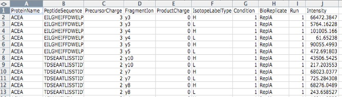

### 2.1.2 Assigning the values of `Condition, BioReplicate` and `Run`

The values of `Condition, BioReplicate, Run` depend on the design of the specific experiment.

#### 1) Group comparison

In a group comparison design, the conditions (e.g., disease states) are profiled across non-overlapping sets of biological replicates (i.e., subjects). In this example there are 2 conditions, Disease and Control (in general the number of conditions can vary). There are 3 subjects (i.e., biological replicates) per condition (in general an equal number of replicates per condition is not required). Each subject has 2 technical replicate runs (in general technical replicates are not required, and their number per sample may vary). Overall, in this example there are \(2 \times 3 \times 2 = 12\) mass spectrometry runs.

Table below shows the values of the columns `Condition, BioReplicate` and `Run` for this situation. It is important to note two things. First, the order of subjects and conditions in the experiment should be randomized, and run id does not need to represent the order of spectral acquisition. Second, the values of the columns are repeated for every quantified transition. For example, if in each run the experiment quantifies 50 endogenous transitions and 50 labeled reference counterparts, then the input file has \(12 \times 50 \times 2 = 1200\) lines. When a feature intensity is missing in a run, the data structure should contain a separate row for each missing value. The rows should include all the information (from `ProteinName` to `Run`), and indicate missing intensities with `NA`.

| `Condition` | `BioReplicate` | `Run` |
| --- | --- | --- |
| Disease | Subject1 | 1 |
| Disease | Subject1 | 2 |
| Disease | Subject2 | 3 |
| Disease | Subject2 | 4 |
| Disease | Subject3 | 5 |
| Disease | Subject3 | 6 |
| Control | Subject4 | 7 |
| Control | Subject4 | 8 |
| Control | Subject5 | 9 |
| Control | Subject5 | 10 |
| Control | Subject6 | 11 |
| Control | Subject6 | 12 |

#### 2) Time course

The important feature of a time course experimental design is that a same subject (i.e., biological replicate) is repetitively measured across multiple time points. In this example there are 2 time points, Time1 and Time2 (in general the number of times can vary). There are 4 subjects (i.e., biological replicates) measured across times (in general an equal number of times per replicate is not required). There are no technical replicates (in general the number of technical replicates per sample may vary). Overall, in this example there are \(2 \times 4 \times 1 = 8\) mass spectrometry runs.

Table below shows the values of the columns `Condition, BioReplicate` and `Run` for this situation. Comments on the order of the runs, on the number of lines in the input data structure, and on the handling of missing peak intensities are as in the group comparison design.

| `Condition` | `BioReplicate` | `Run` |
| --- | --- | --- |
| Time1 | Subject1 | 1 |
| Time2 | Subject1 | 2 |
| Time1 | Subject2 | 3 |
| Time2 | Subject2 | 4 |
| Time1 | Subject3 | 5 |
| Time2 | Subject3 | 6 |
| Time1 | Subject4 | 7 |
| Time2 | Subject4 | 8 |

#### 3) Paired design

Another frequently used experimental design is a *paired design*, where measurements from multiple conditions (such as healthy biopsy and disease biopsy) are taken from a same subject. The statistical model for this experimental design is the same as in the time course experiment, however the values in the columns of the input data may have a different appearence. In this example there are 2 subjects, PatientA and PatientB (in general the number of patients can vary). There are two conditions per subject, BiopsyHealthy and BiopsyTumor (in general the number of conditions per subject can exceed two). In this example there are 3 technical replicates of each type (in this example, the technical replicates are biopsies; in general these can also be replicate sample preparations or replicate mass spectrometry runs). Overall, in this example there are \(2 \times 2 \times 3 = 12\) mass spectrometry runs.

Table below shows the values of the columns `Condition, BioReplicate` and `Run` for this situation. Comments on the order of the runs, on the number of lines in the input data structure, and on the handling of missing peak intensities are as in the group comparison design.

| `Condition` | `BioReplicate` | `Run` |
| --- | --- | --- |
| BiopsyHealthy | PatientA | 1 |
| BiopsyHealthy | PatientA | 2 |
| BiopsyHealthy | PatientA | 3 |
| BiopsyTumor | PatientA | 4 |
| BiopsyTumor | PatientA | 5 |
| BiopsyTumor | PatientA | 6 |
| BiopsyHealthy | PatientB | 7 |
| BiopsyHealthy | PatientB | 8 |
| BiopsyHealthy | PatientB | 9 |
| BiopsyTumor | PatientB | 10 |
| BiopsyTumor | PatientB | 11 |
| BiopsyTumor | PatientB | 12 |

### 2.1.3 `MSnSet` format

`MSstats` also allows data to be in the format of `MSnSet`, which is consistent with the requirements of Bioconductor. The `MSnSet` format has several components, of which the most commonly accessed are `assayData`, `phenoData`, and `featureData`. `assayData` is a matrix of intensities, where each row corresponds a transition, and the columns correspond to sample ids. `phenoData` contains columns that describe the biological samples, conditions in the experiment. `featureData` contains columns describing the peptide features, such as the name or id of the underlying protein and information of features.

If the data are stored in the format `expressionSet`, information for group labels is required. If more than one variable is listed in the argument `group`, then a concatenated variable is created based on all of the specified `group` variables. The remaining information (peptide feature ids, biological replicate ids, and abundance) can be extracted from the rows and columns of `featureData` and `phenoData`, or assigned by the users based on the experimental design.

## 2.2 Label-free DDA

For label-free DDA experiments the required input is the 10-column format, the same as described in section 2.1 for SRM experiments. In DDA experiments spectral features are defined as peptide ions, which are identified and quantified across runs. Since for label-free DDA experiments some of the columns `PeptideSequence`, `PrecursorCharge`, `FragmentIon`, and `ProductCharge` are not relevant, these columns will have a constant fixed value (such as `NA`) across the entire dataset. Furthermore, the column `IsotopeLabelType` will be set to “L” for the entire dataset.

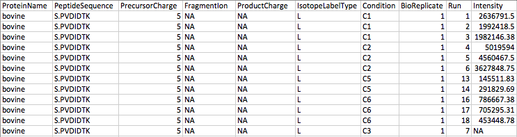

## 2.2 Label-free DIA

For label-free DIA experiments, the required input is the 10-column format, the same as described in section 2.1 for SRM experiments. The values of the required columns can be extracted from the output of signal processing software such as Skyline or OpenSWATH. By default, the combination of the values in the columns `PeptideSequence, PrecursorCharge, FragmentIon, ProductCharge` uniquely identifies each spectral feature (i.e., a fragment ion identified and quantified across multiple runs). If the signal processing software does not provide the information on some of these columns but provides a unique feature identifier, it is possible to use this unique identifier instead of one of these columns. Furthermore, the column `IsotopeLabelType` is set to “L” for the entire dataset.

An example dataset is shown below. In this example, feature id generated by OpenSWATH is used instead of `ProductCharge` to uniquely characterize each feature.

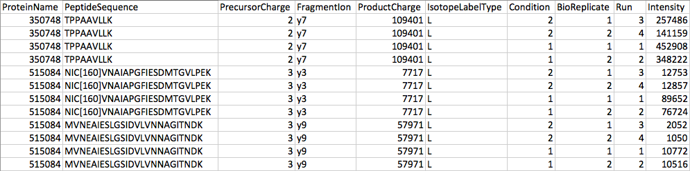

# 3. Prerequisites and setting for MSstats analysis

`MSstats` is an R-based package. It is assumed that you already have R installed. You can downlaod the package from the [MSstats installation page](http://msstats.org/installation/) and install it as follows:

```r
install.packages(pkgs = 'MSstats_3.0.9.tar.gz', repos = NULL, type = 'source')
```

Alternatively, you can install `MSstats` from Bioconductor:

```r
source("https://bioconductor.org/biocLite.R")
biocLite("MSstats")
```

Once you have the package installed, load `MSstats` into an R session and verify that you have the correct version (3.0.9). Note that in order to use `MSstats`, the package needs to be loaded every time you restart R.

```r
library('MSstats', warn.conflicts = F, quietly = T, verbose = F)
?MSstats
```

Finally, set the working directory to where you saved files. Note that you may have a different path on your computer from the example.

```r
setwd('/Users/Meena/Dropbox/MSstats_GitHub_document')
```

# 4. DDA analysis with MSstats

This section describes a typical workflow for DDA analysis with `MSstats`. Controlled mixture DDA data will be used for demonstration. This dataset (RawData.DDA.csv) is available in [MSstats material GitHub](https://github.com/MeenaChoi/MSstats_material) in the folder named 'example dataset/DDA_controlledMixture2009'. It is processed by Superhirn. [original reference link](http://prottools.ethz.ch/muellelu/web/Latin_Square_Data.php)

## 4.1 Preparing the data for MSstats input

The first step in using the `MSstats` is to format the data as described in Section 2. We load here the prepared example dataset and confirm the data is stored in the correct format.

```r
DDA2009.superhirn <- DDARawData

head(DDA2009.superhirn)
```

```
##   ProteinName PeptideSequence PrecursorCharge FragmentIon ProductCharge
## 1      bovine     S.PVDIDTK_5              NA           5            NA
## 2      bovine     S.PVDIDTK_5              NA           5            NA
## 3      bovine     S.PVDIDTK_5              NA           5            NA
## 4      bovine     S.PVDIDTK_5              NA           5            NA
## 5      bovine     S.PVDIDTK_5              NA           5            NA
## 6      bovine     S.PVDIDTK_5              NA           5            NA
##   IsotopeLabelType Condition BioReplicate Run Intensity
## 1                L        C1            1   1   2636792
## 2                L        C1            1   2   1992418
## 3                L        C1            1   3   1982146
## 4                L        C2            1   4   5019594
## 5                L        C2            1   5   4560468
## 6                L        C2            1   6   3627849
```

## 4.2 Processing the data

### 4.2.1 Normalizing and summarizing data with dataProcess

To get started with this function, visit the help section of `dataProcess` first:

```
?dataProcess
```

#### 4.2.1.1 Default normalization and summarization options

`dataProcess` provides a variety of options in consideration of different experimental protocols. Therefore, the default options may not be appropriate for all possible scenarios. It is important to understand their underlying assumption to avoid misuse.

The default option for normalization is `equalizeMedians`, where all the intensities in a run are shifted by a constant, to equalize the median of intensities across runs for label-free experiment. This normalization method is appropriate when the majority of proteins do not change across runs. Be cautious when using the `equalizeMedians` option for a label-free DDA dataset with only a small number of proteins. Instead, if you have a spiked in standard, you may set this to `globalStandards` and define the standard with `nameStandards`. For label based experiment, `equalizeMedians` equalizes the median of reference intensities across runs and is generally proper even for a dataset with a small number of proteins.

A typical label-free DDA dataset may have many missing values and noisy features with outliers. `MSstats` supports several ways to deal with this. The default option for summarization is `TMP` (Tukey's median polish, robust parameter estimation method with median across rows and columns) after imputation by AFT (accelerated failure time model, `MBimpute=TRUE`) based on censored intensity for `NA` (`censoredInt="NA"`) with a cutoff as the minimum value for a feature and a run (`cutoffCensored="minFeatureNRun"`). Here the `NA` values represent censored measurements, which are below the cutoff and undetectable. This process handles missing values through imputation and reduces the influence of the outliers using the `TMP` estimation. Note, however, that those runs with no measurements at all will be removed and not be used for any calculation.

```r
# default option
DDA2009.TMP <- dataProcess(raw = DDA2009.superhirn,  fillIncompleteRows = TRUE,
                           normalization = 'equalizeMedians',
                           summaryMethod = 'TMP',
                           censoredInt = "NA", cutoffCensored = "minFeatureNRun",
                           MBimpute = TRUE)
```

```
## * Use all features that the dataset origianally has.
```

```
##
##   Summary of Features :
##                          count
## # of Protein                 6
## # of Peptides/Protein    11-32
## # of Transitions/Peptide   1-1
##
##   Summary of Samples :
##                            C1 C2 C3 C4 C5 C6
## # of MS runs                3  3  3  3  3  3
## # of Biological Replicates  1  1  1  1  1  1
## # of Technical Replicates   3  3  3  3  3  3
```

```
##
##  Summary of Missingness :
##
##   # transitions are completely missing in one condition: 90
##
##     -> D.GPLTGTYR_23_NA_23_NA, F.HFHWGSSDDQGSEHTVDR_402_NA_402_NA, G.PLTGTYR_8_NA_8_NA, H.SFNVEYDDSQDK_465_NA_465_NA, K.AVVQDPALKPL_156_NA_156_NA, K.KYAAELHLVHWNTK_700_NA_700_NA, K.VGDANPALQK_68_NA_68_NA, K.VLDALDSIK_52_NA_52_NA, K.YAAELHLVHWNTK_577_NA_577_NA, L.ALVYGEATSR_88_NA_88_NA, L.ANWRPAQP…
##
##   # run with 75% missing observations: 0
##
##
##  == Start the summarization per subplot...
## Getting the summarization by Tukey's median polish per subplot for protein  bovine ( 1  of  6 )
## Getting the summarization by Tukey's median polish per subplot for protein  chicken ( 2  of  6 )
## Getting the summarization by Tukey's median polish per subplot for protein  cyc_horse ( 3  of  6 )
## Getting the summarization by Tukey's median polish per subplot for protein  myg_horse ( 4  of  6 )
## Getting the summarization by Tukey's median polish per subplot for protein  rabbit ( 5  of  6 )
## Getting the summarization by Tukey's median polish per subplot for protein  yeast ( 6  of  6 )
##
##  == the summarization per subplot is done.
```

If `MBimpute=FALSE`, imputation will not be performed and censored intensities (here `NA`'s) will be replaced with a cutoff value specified in `cutoffCensored`. The default option for `cutoffCensored` is `minFeatureNRun`, taking the minimum value for the corresponding feature and run. With this option, those runs with substantial missing measurements will be biased by the cutoff value. In such case, you may remove the runs that have more than 50% missing values from the analysis with the option `remove50missing=TRUE`.

Output of the `dataProcess` function contains the processed and run-level summarized data as well as relevant information for the summarization step.

```r
names(DDA2009.TMP)
```

```
## [1] "ProcessedData"     "RunlevelData"      "SummaryMethod"
## [4] "ModelQC"           "PredictBySurvival"
```

```r
# the data after reformatting and normalization
head(DDA2009.TMP$ProcessedData)
```

```
##      PROTEIN                     PEPTIDE TRANSITION
## 55    bovine            D.GPLTGTYR_23_NA      23_NA
## 937   bovine F.HFHWGSSDDQGSEHTVDR_402_NA     402_NA
## 1628  bovine   F.HWGSSDDQGSEHTVDR_229_NA     229_NA
## 19    bovine              G.PLTGTYR_8_NA       8_NA
## 1081  bovine       H.SFNVEYDDSQDK_465_NA     465_NA
## 469   bovine        K.AVVQDPALKPL_156_NA     156_NA
##                                 FEATURE LABEL GROUP_ORIGINAL
## 55               D.GPLTGTYR_23_NA_23_NA     L             C1
## 937  F.HFHWGSSDDQGSEHTVDR_402_NA_402_NA     L             C1
## 1628   F.HWGSSDDQGSEHTVDR_229_NA_229_NA     L             C1
## 19                  G.PLTGTYR_8_NA_8_NA     L             C1
## 1081       H.SFNVEYDDSQDK_465_NA_465_NA     L             C1
## 469         K.AVVQDPALKPL_156_NA_156_NA     L             C1
##      SUBJECT_ORIGINAL RUN GROUP SUBJECT SUBJECT_NESTED INTENSITY ABUNDANCE
## 55                  1   1     1       1            1.1  757400.1  19.79517
## 937                 1   1     1       1            1.1 2087125.8  21.25756
## 1628                1   1     1       1            1.1 1485145.8  20.76665
## 19                  1   1     1       1            1.1 4986404.0  22.51404
## 1081                1   1     1       1            1.1 2488141.2  21.51111
## 469                 1   1     1       1            1.1 7519322.0  23.10664
##      METHOD
## 55        1
## 937       1
## 1628      1
## 19        1
## 1081      1
## 469       1
```

```r
# run-level summarized data
head(DDA2009.TMP$RunlevelData)
```

```
##   RUN   Protein LogIntensities more50missing GROUP GROUP_ORIGINAL
## 1   1    bovine       21.25800         FALSE     1             C1
## 2   1 myg_horse       22.77386         FALSE     1             C1
## 3   1    rabbit       12.54786          TRUE     1             C1
## 4   1     yeast       16.44018          TRUE     1             C1
## 5   1   chicken       18.29509         FALSE     1             C1
## 6   1 cyc_horse       19.49460         FALSE     1             C1
##   SUBJECT_ORIGINAL SUBJECT_NESTED SUBJECT
## 1                1            1.1       1
## 2                1            1.1       1
## 3                1            1.1       1
## 4                1            1.1       1
## 5                1            1.1       1
## 6                1            1.1       1
```

```r
# Since this is not model-based, no model summary (here DDAskyline.quant$ModelQC=NULL).
# Only with 'summaryMethod="linear"'
head(DDA2009.TMP$ModelQC)
```

```r
# here 'TMP'
head(DDA2009.TMP$SummaryMethod)
```

```
## [1] "TMP"
```

```r
# predict values by AFT with 'MBimpute=TRUE'.
# These values are matching with rownames of DDA2009.TMP$ProcessedData
head(DDA2009.TMP$PredictBySurvival)
```

```
##       55      937     1628       19     1081      469
## 19.63438 22.40369 21.67132 23.52286 21.55629 23.11901
```

If `censoredInt=NULL`, we assume that all intensities are missing at random and there is no action for missing values.

```r
# no action for missing values.
DDA2009.TMP.random <- dataProcess(raw = DDA2009.superhirn, fillIncompleteRows = TRUE,
                                  normalization = 'equalizeMedians',
                                  summaryMethod = 'TMP',
                                  censoredInt=NULL)
```

```
## * Use all features that the dataset origianally has.
```

```
##
##   Summary of Features :
##                          count
## # of Protein                 6
## # of Peptides/Protein    11-32
## # of Transitions/Peptide   1-1
##
##   Summary of Samples :
##                            C1 C2 C3 C4 C5 C6
## # of MS runs                3  3  3  3  3  3
## # of Biological Replicates  1  1  1  1  1  1
## # of Technical Replicates   3  3  3  3  3  3
```

```
##
##  Summary of Missingness :
##
##   # transitions are completely missing in one condition: 90
##
##     -> D.GPLTGTYR_23_NA_23_NA, F.HFHWGSSDDQGSEHTVDR_402_NA_402_NA, G.PLTGTYR_8_NA_8_NA, H.SFNVEYDDSQDK_465_NA_465_NA, K.AVVQDPALKPL_156_NA_156_NA, K.KYAAELHLVHWNTK_700_NA_700_NA, K.VGDANPALQK_68_NA_68_NA, K.VLDALDSIK_52_NA_52_NA, K.YAAELHLVHWNTK_577_NA_577_NA, L.ALVYGEATSR_88_NA_88_NA, L.ANWRPAQP…
##
##   # run with 75% missing observations: 0
##
##
##  == Start the summarization per subplot...
## Getting the summarization by Tukey's median polish per subplot for protein  bovine ( 1  of  6 )
## Getting the summarization by Tukey's median polish per subplot for protein  chicken ( 2  of  6 )
## Getting the summarization by Tukey's median polish per subplot for protein  cyc_horse ( 3  of  6 )
## Getting the summarization by Tukey's median polish per subplot for protein  myg_horse ( 4  of  6 )
## Getting the summarization by Tukey's median polish per subplot for protein  rabbit ( 5  of  6 )
## Getting the summarization by Tukey's median polish per subplot for protein  yeast ( 6  of  6 )
##
##  == the summarization per subplot is done.
```

#### 4.2.1.2 Different summarization options

```r
# linear mixed model (lm or lmer) with run and feature
DDA2009.linear <- dataProcess(raw = DDA2009.superhirn,
                              summaryMethod = "linear", censoredInt = NULL)

# accerated failure model with left-censored. NA intensities are assumed as censored
DDA2009.linear.censored <- dataProcess(raw = DDA2009.superhirn,
                                       summaryMethod = "linear", censoredInt = "NA")
```

### 4.2.2 Visualization of processed data

#### 4.2.2.1 Quality control and normalization effects

QC plots are used to assess the effects of the normalization step. These plots can be generated for either all proteins at once or each protein individually if we have a large dataset. The example below shows both options.

```r
# use type="QCplot" with all proteins and change the upper limit of y-axis=35
dataProcessPlots(data = DDA2009.TMP, type="QCplot", ylimUp=35)
```

```r
# QCplot for only 'yeast' protein
dataProcessPlots(data = DDA2009.TMP, type="QCplot", ylimUp=35,
                 which.Protein="yeast", address="yeast_eqmedians_")
```

[figure not shown]

*NOTE* Don't worry about warning messages as below. It means `NA` values are not included in the plot, which is a proper way for this case.

```
Warning messages:
1: In loop_apply(n, do.ply) :
  Removed 698 rows containing non-finite values (stat_boxplot).
```

#### 4.2.2.2 Summarization effects

##### Profile plots

Profile plots present the effects of the summarization step by showing all individual measurements of a protein and their summarized intensity. With `type="profileplot"`, two pdfs will be generated. The first pdf includes plots (per protein) to show individual measurement for each peptide (peptide for DDA, transition for SRM or DIA) across runs, grouped per condition. Each peptide has a different color/type layout. To ignore these plots, please use the option `originalPlot=FALSE`. The second pdf, which is named with 'wSummarization' suffix, shows run-level summarized data per protein. The same peptides (or transition) in the first plot are presented in grey, with the summarized values (by TMP, in this example) overlaid in red.

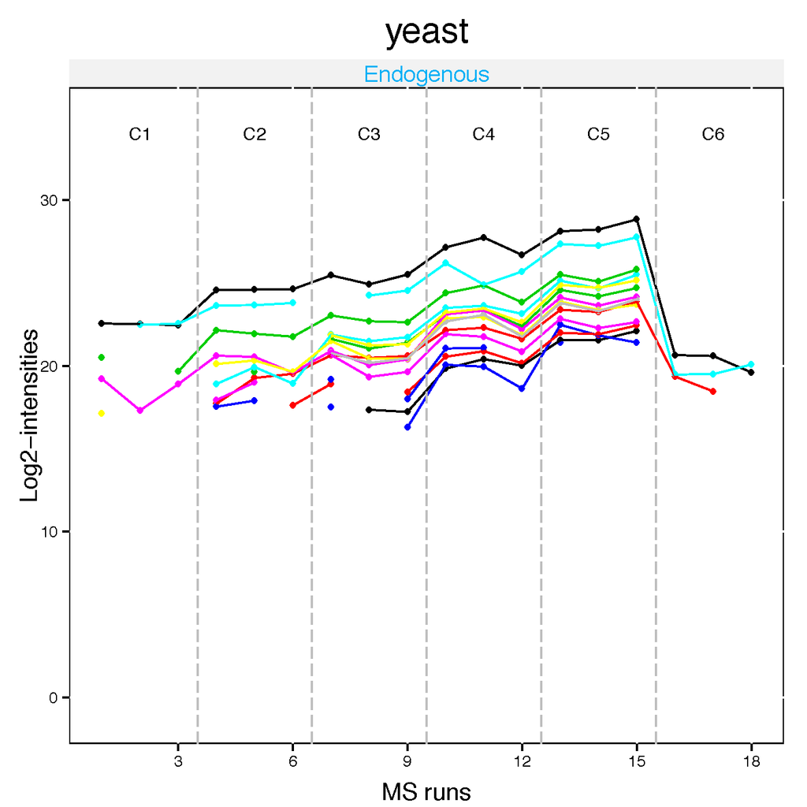

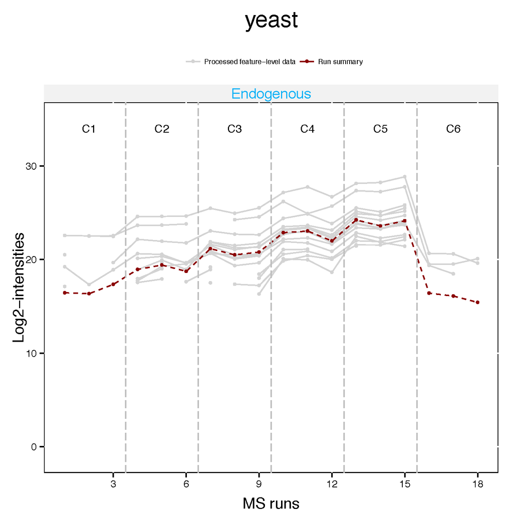

```r
dataProcessPlots(data = DDA2009.TMP, type="Profileplot",  ylimUp=35,
                 featureName="NA", width=7, height=7, address="DDA2009_TMP_")
```

These plots can be used compare and select among different options for summarization (e.g., `TMP` with or without considering missing values for summarization in `dataProcess`). While original profile plots are the same, summarization plots reveal differences, especially for conditions 'C1' and 'C2' in 'yeast' protein, which have many missing values.

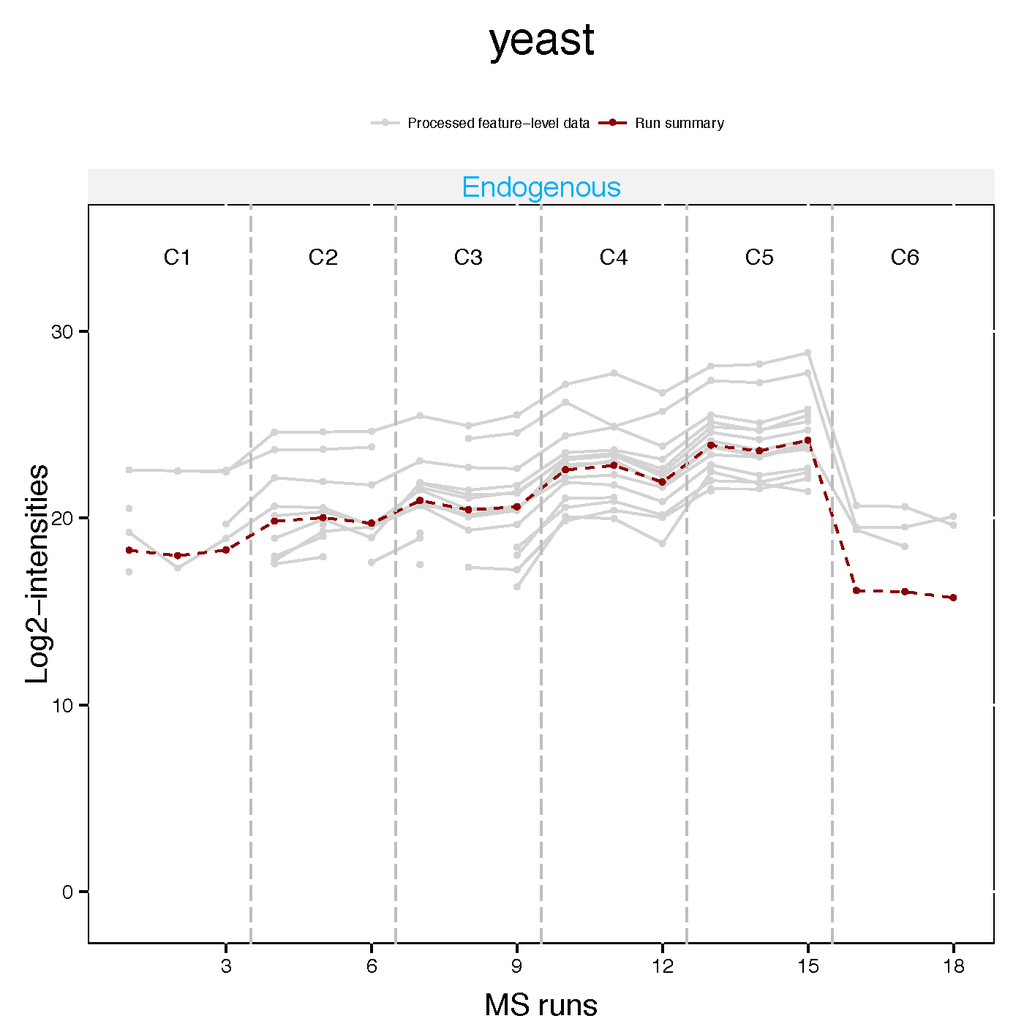

```r
dataProcessPlots(data = DDA2009.TMP.random, type="Profileplot",  ylimUp=35,
                 featureName="NA", width=7, height=7,
                 originalPlot=FALSE, summaryPlot=TRUE, address="DDA2009_TMP_random_")
```

## 4.3 Finding differentially abundant proteins across conditions

### 4.3.1 Comparing conditions with groupComparison

With the normalized data and run-level summarized data obtained by applying one of the `dataProcess` summarization methods, it is of general interest to find proteins changing between groups of conditions. Within `MSstats` this can be done by using the `groupComparison` function, which takes as input the output of the `dataProcess` function.

```r
?groupComparison
```

In addition to the processed data, the `groupComparison` function requires a contrast matrix to define the comparison to be made. The contrast matrix is created with each condition in column and each comparison in row. Note that the conditions are arranged **in alphabetical order**. The order of condition that `MSstats` recognizes can be shown by using `levels`:

```r
levels(DDA2009.TMP$ProcessedData$GROUP_ORIGINAL)
```

```
## [1] "C1" "C2" "C3" "C4" "C5" "C6"
```

Entries in each row of the contrast matrix are filled in with 0, 1, or -1 to specify the comparison, where **0** is for conditions we would like to ignore, **1** is for conditions we would like to put in the numerator of the ratio or fold-change, and **-1** is for conditions we would like to put in the denumerator of the ratio or fold-change.

For example, if you want to compare C2-C1, which means log(C2)-log(C1) and the same as log(C2/C1), set '1' for C2 and '-1' for C1 in the row. Combining multiple groups for comparison is also possible. For example, if you want to compare between average of C2 and C3 and average of C1, (C3+C2)/2-C1 as formula, set '-1' for C1, '0.5' for C2 and '0.5' for C3, and '0' for rest of groups.

```r
comparison1<-matrix(c(-1,1,0,0,0,0),nrow=1)
comparison2<-matrix(c(0,-1,1,0,0,0),nrow=1)
comparison3<-matrix(c(0,0,-1,1,0,0),nrow=1)
comparison4<-matrix(c(0,0,0,-1,1,0),nrow=1)
comparison5<-matrix(c(0,0,0,0,-1,1),nrow=1)
comparison6<-matrix(c(1,0,0,0,0,-1),nrow=1)

comparison<-rbind(comparison1,comparison2,comparison3,comparison4,comparison5,comparison6)
row.names(comparison)<-c("C2-C1","C3-C2","C4-C3","C5-C4","C6-C5","C1-C6")
```

With the contrast matrix specified, group comparison can be performed as follows.

```r
DDA2009.comparisons <- groupComparison(contrast.matrix = comparison, data = DDA2009.TMP)
```

Output of the `groupComparison` function contains three data frames:

```r
# output from groupComparison function has three data frames
names(DDA2009.comparisons)
```

```
## [1] "ComparisonResult" "ModelQC"          "fittedmodel"
```

Results of the statistical comparison are stored in the data frame named `ComparisonResult`:

```r
# name of columns in result data.frame
names(DDA2009.comparisons$ComparisonResult)
```

```
## [1] "Protein"    "Label"      "log2FC"     "SE"         "Tvalue"
## [6] "DF"         "pvalue"     "adj.pvalue"
```

Based on the comparison results and desired significance level, a short list of the differentially abundant proteins can be obtained for further investigation:

```r
# get only significant proteins and comparisons among all comparisons
SignificantProteins <- with(DDA2009.comparisons, ComparisonResult[ComparisonResult$adj.pvalue < 0.05, ])
nrow(SignificantProteins)
```

```
## [1] 33
```

### 4.3.2 Visualization of differentially abundant proteins

```r
?groupComparisonPlots
```

Volcano plots visualize the outcome of one comparison between conditions for all the proteins, and combine the information on statistical and practical significance. The y-axis displays the FDR-adjusted p-values on the negative log10 scale, representing statistical significance. The horizontal dashed line shows the FDR cutoff. The points above the FDR cutoff line are statistically significant proteins that are differentially abundant across conditions. These points are colored in red and blue for upregulated and downregulated proteins, respectively. The x-axis is the model-based estimate of fold change on log scale (the base of logarithm transform is the same as specified in the `logTrans` option of the `dataProcess` function), and represents practical significance. It is possible to specify a practical significance cutoff based on the estimate of fold change in addition to the statistical significance cutoff. If the fold change cutoff is specified, the points above the horizontal cutoff line but within the vertical cutoff line will be considered as not differentially abundant (and will be colored in black). The practical significance cutoff should only be applied in addition to the statistical significance cutoff (i.e., the fold change alone does not present enough evidence for differential abundance).

```r
groupComparisonPlots(data = DDA2009.comparisons$ComparisonResult, type = 'VolcanoPlot')
```

'VolcanoPlot.pdf' will be saved under the folder you assigned. It has the plots per comparison defined in `contrast.matrix`. Below is one of volcano plots, for comparison 'C6-C5'. Please check `?groupComparisonPlots` for detail, such as labelling protein names, size of dots, font sizes, etc.

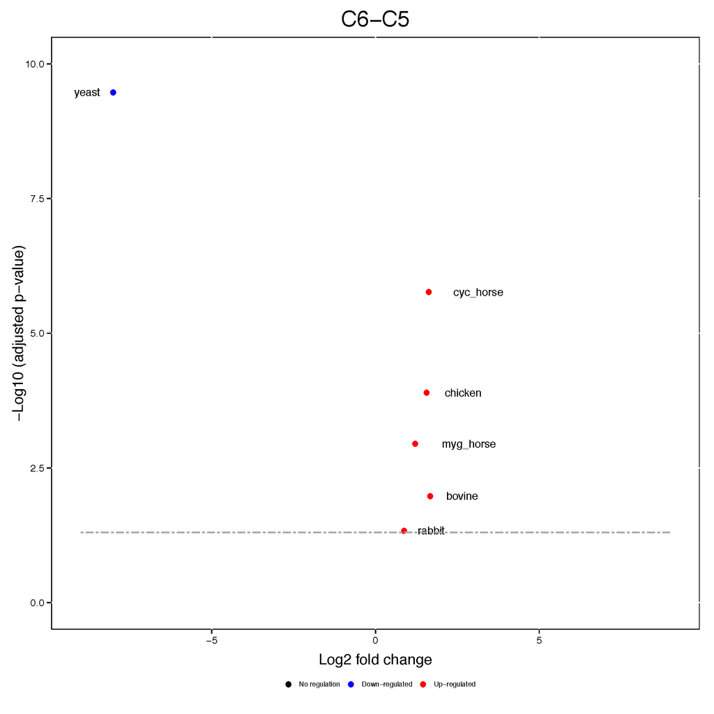

Heatmaps illustrate the patterns of up- and down-regulation of proteins in several comparisons. Columns in the heatmaps are comparison of conditions assigned in `contrast.matrix`, and rows are proteins. The heatmaps display signed FDR-adjusted p-values of the tests, colored in red/blue for significantly up-/down-regulated proteins, while taking into account the specified FDR cutoff and the additional optional fold change cutoff. Brighter colors indicate stronger evidence in favor of differential abundance. Black color represents proteins that are not significantly differentially abundant.

```r
groupComparisonPlots(data = DDA2009.comparisons$ComparisonResult, type = 'Heatmap')
```

'Heatmap.pdf' will be saved under the folder you assigned. It has the plots per comparison defined in `contrast.matrix`. Below is one example, showing the results for several comparisons simultaneously. For further details, such as labelling protein names, size of dots, font sizes, etc., please check `?groupComparisonPlots`.

[figure not shown]

# 5. Convert Skyline output to MSstats required format

This section describes steps and considerations to properly format data processed by Skyline, prior to the `MSstats` analysis. In the following example, the same raw dataset from the previous section is used, but it is processed by Skyline.

## 5.1 Preparing the data for MSstats input

As in the previous example, we first load and access the dataset processed by Skyline:

```r
raw<-DDARawData.Skyline
```

The input data for `MSstats` is required to contain variables of `ProteinName`, `PeptideSequence`, `PrecursorCharge`, `FragmentIon`, `ProductCharge`, `IsotopeLabelType`, `Condition`, `BioReplicate`, `Run`, `Intensity`. These variable names should be fixed. `MSstats` input from Skyline adapts the column scheme of the dataset so that it fits `MSstats` input format. However two column names need to be changed: from `FileName` to `Run` and from `Area` to `Intensity`.

```r
colnames(raw)[9] <- 'Run'
colnames(raw)[10] <- 'Intensity'
head(raw)
```

```
##   ProteinName  PeptideSequence PrecursorCharge FragmentIon ProductCharge
## 1      bovine HWGSSDDQGSEHTVDR               2   precursor             2
## 2      bovine HWGSSDDQGSEHTVDR               2   precursor             2
## 3      bovine HWGSSDDQGSEHTVDR               2   precursor             2
## 4      bovine HWGSSDDQGSEHTVDR               2   precursor             2
## 5      bovine HWGSSDDQGSEHTVDR               2   precursor             2
## 6      bovine HWGSSDDQGSEHTVDR               2   precursor             2
##   IsotopeLabelType Condition BioReplicate              Run Intensity
## 1            light         1            1 B06-8004_c.mzXML   1015466
## 2            light         3            2 B06-8006_c.mzXML    907841
## 3            light         5            3 B06-8008_c.mzXML   1263905
## 4            light         2            4 B06-8010_c.mzXML   2457121
## 5            light         4            5 B06-8012_c.mzXML    958204
## 6            light         6            6 B06-8014_c.mzXML    788090
##   StandardType Truncated
## 1           NA     False
## 2           NA     False
## 3           NA     False
## 4           NA     False
## 5           NA     False
## 6           NA     False
```

The difference between output from Skyline and other spectral processing tool is that Skyline distinguishes random missing (`NA`) and censored missing (zero). The output from Skyline can have `NA` (expect small number of `NA`'s or none of them) and 0 (zero). Thus, we can use zero values in `Intensity` as censored.

```r
sum(is.na(raw$Intensity))
```

```
## [1] 0
```

```r
sum(raw$Intensity==0)
```

```
## [1] 4326
```

### 5.2 Preprocessing with DDA experiment from Skyline output

The output from Skyline for DDA experiment needs one extra step before using `MSstats`. It has several measurements of peak area from the monoisotopic, M+1 and M+2 peaks. To get a robust measure of peptide intensity, we can sum over isotopic peaks per peptide or use the highest peak. Here we take a summation per peptide.

```r
library(reshape2)

raw$pepprecursor<-paste(raw$PeptideSequence, raw$PrecursorCharge, sep="_")

data_w = dcast( Run ~ pepprecursor, data=raw, value.var='Intensity', fun.aggregate=sum, fill=NULL)

newdata = melt(data_w, id.vars=c('Run'))
colnames(newdata)[colnames(newdata) %in% c("variable","value")]<-c('pepprecursor','Intensity')

uniinfo<-unique(raw[,c("ProteinName","PeptideSequence","PrecursorCharge","pepprecursor")])
newraw<-merge(newdata,uniinfo, by="pepprecursor")

uniinfo<-unique(raw[,c("Run","BioReplicate","Condition")])
newraw<-merge(newraw,uniinfo, by="Run")

newraw$BioReplicate<-1 # it should be change based on your experiment.
newraw$FragmentIon<-"sum"
newraw$ProductCharge<-NA
newraw$IsotopeLabelType<-"L"

raw<-newraw
# now 'raw' is ready to use MSstats
```

### 5.3 Different options for Skyline in dataProcess

Additional options in `dataProcess` that need to be specified for processing Skyline output are `skylineReport=TRUE` (to remove `Truncated=TRUE` rows and handle intensity=0) and `censoredInt="0"` (to use intensity=0 as censored to handle missing values and in this case, `NA` values are assumed as random missing).

# 6. Convert MaxQuant output to MSstats required input

The following R code chunks show steps to format a MaxQuant output for analysis by `MSstats`. Here a controlled mixture dataset with dynamic range benchmark (Cox, 2014 in MCP) is used for demonstration. This dataset is available in [MSstats material GitHub](https://github.com/MeenaChoi/MSstats_material) under the folder named 'example dataset/DDA_controlledMixture20014'.

```r
## 1. First, get protein ID information
proteinGroups <- read.table("DDA2014_proteinGroups.txt", sep = "\t", header = TRUE)
```

```r
## 2. Read in annotation including condition and biological replicates: annotation.csv
annot <- read.csv("DDA2014_annotation.csv", header = TRUE)
```

```r
## 3. Read in MaxQuant file: evidence.txt
infile <- read.table("evidence.txt", sep = "\t", header = TRUE)
```

```r
## 4. Reformat for MSstats required input
##    check options for converting format
?MaxQtoMSstatsFormat
```

```r
msstats.raw <- MaxQtoMSstatsFormat(evidence=infile, annotation=annot, proteinGroups=proteinGroups)

## now 'msstats.raw' is ready for MSstats
```